# GGlasso Model Validation: Predicting IBD Flares Using Group Lasso

2025-12-26

This analysis develops predictive models for inflammatory bowel disease (IBD) flares at four different time points using a sophisticated group-based variable selection approach.

# 1. Data Loading and Preparation

## 1.1 Initial Data Sources

The code integrates multiple datasets:

- Disease-specific data: Separate datasets for Crohn’s Disease (CD) and Ulcerative Colitis (UC)
- Psychosocial variables: IBD Control questionnaire (fatigue, depression, anxiety) and Health Monitor (stress)
- Medication data: Advanced therapy use and other medications with treatment periods

```r
# Import Excel files
dataset_cd <- read_excel("Dataset CD v5.xlsx") %>%
  mutate(birthdate = dmy(birthdate))

dataset_uc <- read_excel("Dataset UC v5.xlsx") %>%
  mutate(birthdate = dmy(birthdate))


# psychosocial variables
Health_Monitor <- read_excel("Health Monitor.xlsx")
IBD_Control  <- read_excel("IBD Control.xlsx")

# therapy use
Other_medication<- read_excel("Other medication v4.xlsx")
advanced_therapy_use <- read_excel("Advanced therapy use v4.xlsx")
```

The psychosocial variables such as:

- Fatigue (is in the IBDcontrol folder–> each of the score in the column should be multiplied by 2 (eg 1*2 =2, 2*2 = 4 and so on, to be about the same with the fatigue variables in the initial model)–*Don’t use the values in the VAS fatigue folder for this
- Depression (is in the IBDcontrol folder)
- Anxiety (is in the IBDcontrol folder)
- Stress (is in the Health Monitor folder
- use the column called “control myself’’ for this) - Smoking Status - is in the Dataset CD and UC as smoker.

## 1.2 Calprotectin Processing

A critical feature engineering step identifies the maximum calprotectin value within 6 months of each MIAH assessment date. This biomarker is crucial for detecting intestinal inflammation.

```r
# Function to find max calprotectin within 6 months for one MIAH date
find_max_calpro <- function(row_data, miah_date_col) {

  # Get the MIAH date
  miah_date <- row_data[[miah_date_col]]

  # If MIAH date is NA, return NA
  if (is.na(miah_date)) {
    return(list(date = as.POSIXct(NA), value = NA_real_))
  }

  # Collect all calprotectin values and dates
  calpro_values <- c()
  calpro_dates <- c()

  for (i in 1:16) {
    val_col <- paste0("calprotectine", i)
    date_col <- paste0("calpro_date", i)

    if (!is.null(row_data[[val_col]]) && !is.na(row_data[[val_col]])) {
      if (!is.null(row_data[[date_col]]) && !is.na(row_data[[date_col]])) {
        calpro_values <- c(calpro_values, as.numeric(row_data[[val_col]]))
        calpro_dates <- c(calpro_dates, as.POSIXct(row_data[[date_col]]))
      }
    }
  }

  # If no valid calprotectin data, return NA
  if (length(calpro_values) == 0) {
    return(list(date = as.POSIXct(NA), value = NA_real_))
  }

  # Calculate days difference (difftime works with POSIXct)
  days_diff <- abs(as.numeric(difftime(calpro_dates, miah_date, units = "days")))

  # Filter for within 6 months (183 days)
  within_6m <- days_diff <= 183

  if (sum(within_6m) == 0) {
    return(list(date = as.POSIXct(NA), value = NA_real_))
  }

  # Get values and dates within 6 months
  valid_values <- calpro_values[within_6m]
  valid_dates <- calpro_dates[within_6m]

  # Find maximum value
  max_idx <- which.max(valid_values)

  return(list(date = valid_dates[max_idx], value = valid_values[max_idx]))
}
```

```r
# Process for miah_date1
dataset_cd$date1_calprotectine <- as.POSIXct(rep(NA, nrow(dataset_cd)))
dataset_cd$value_calprotectine_1 <- NA_real_

for (i in 1:nrow(dataset_cd)) {
  result <- find_max_calpro(dataset_cd[i, ], "miah_date1")
  dataset_cd$date1_calprotectine[i] <- result$date
  dataset_cd$value_calprotectine_1[i] <- result$value
}
# Ensure POSIXct class is preserved
class(dataset_cd$date1_calprotectine) <- c("POSIXct", "POSIXt")

# Process for miah_date2
dataset_cd$date2_calprotectine <- as.POSIXct(rep(NA, nrow(dataset_cd)))
dataset_cd$value_calprotectine_2 <- NA_real_

for (i in 1:nrow(dataset_cd)) {
  result <- find_max_calpro(dataset_cd[i, ], "miah_date2")
  dataset_cd$date2_calprotectine[i] <- result$date
  dataset_cd$value_calprotectine_2[i] <- result$value
}
class(dataset_cd$date2_calprotectine) <- c("POSIXct", "POSIXt")

# Process for miah_date3
dataset_cd$date3_calprotectine <- as.POSIXct(rep(NA, nrow(dataset_cd)))
dataset_cd$value_calprotectine_3 <- NA_real_

for (i in 1:nrow(dataset_cd)) {
  result <- find_max_calpro(dataset_cd[i, ], "miah_date3")
  dataset_cd$date3_calprotectine[i] <- result$date
  dataset_cd$value_calprotectine_3[i] <- result$value
}
class(dataset_cd$date3_calprotectine) <- c("POSIXct", "POSIXt")

# Process for miah_date4
dataset_cd$date4_calprotectine <- as.POSIXct(rep(NA, nrow(dataset_cd)))
dataset_cd$value_calprotectine_4 <- NA_real_

for (i in 1:nrow(dataset_cd)) {
  result <- find_max_calpro(dataset_cd[i, ], "miah_date4")
  dataset_cd$date4_calprotectine[i] <- result$date
  dataset_cd$value_calprotectine_4[i] <- result$value
}
class(dataset_cd$date4_calprotectine) <- c("POSIXct", "POSIXt")

# View results
result_cols <- c("miah_date1", "date1_calprotectine", "value_calprotectine_1",
                 "miah_date2", "date2_calprotectine", "value_calprotectine_2",
                 "miah_date3", "date3_calprotectine", "value_calprotectine_3",
                 "miah_date4", "date4_calprotectine", "value_calprotectine_4")

head(dataset_cd[, result_cols])

# DROP 16 calpro
dataset_cd <- dataset_cd %>%
  select(-starts_with(c("calpro")))

## # A tibble: 6 × 12
##   miah_date1          date1_calprotectine value_calprotectine_1
##   <dttm>              <dttm>                              <dbl>
## 1 2023-11-19 00:00:00 2023-11-01 01:00:00                    24
## 2 NA                  NA                                     NA
## 3 2024-12-16 00:00:00 2025-03-04 01:00:00                   100
## 4 2024-04-29 00:00:00 2024-04-02 01:00:00                   190
## 5 2023-11-26 00:00:00 2023-10-09 01:00:00                   510
## 6 2023-11-19 00:00:00 2023-08-09 01:00:00                   270
## # ℹ 9 more variables: miah_date2 <dttm>, date2_calprotectine <dttm>,
## #   value_calprotectine_2 <dbl>, miah_date3 <dttm>, date3_calprotectine <dttm>,
## #   value_calprotectine_3 <dbl>, miah_date4 <dttm>, date4_calprotectine <dttm>,
## #   value_calprotectine_4 <dbl>
```

```r
# Process for miah_date1
dataset_uc$date1_calprotectine <- as.POSIXct(rep(NA, nrow(dataset_uc)))
dataset_uc$value_calprotectine_1 <- NA_real_

for (i in 1:nrow(dataset_uc)) {
  result <- find_max_calpro(dataset_uc[i, ], "miah_date1")
  dataset_uc$date1_calprotectine[i] <- result$date
  dataset_uc$value_calprotectine_1[i] <- result$value
}
# Ensure POSIXct class is preserved
class(dataset_uc$date1_calprotectine) <- c("POSIXct", "POSIXt")

# Process for miah_date2
dataset_uc$date2_calprotectine <- as.POSIXct(rep(NA, nrow(dataset_uc)))
dataset_uc$value_calprotectine_2 <- NA_real_

for (i in 1:nrow(dataset_uc)) {
  result <- find_max_calpro(dataset_uc[i, ], "miah_date2")
  dataset_uc$date2_calprotectine[i] <- result$date
  dataset_uc$value_calprotectine_2[i] <- result$value
}
class(dataset_uc$date2_calprotectine) <- c("POSIXct", "POSIXt")

# Process for miah_date3
dataset_uc$date3_calprotectine <- as.POSIXct(rep(NA, nrow(dataset_uc)))
dataset_uc$value_calprotectine_3 <- NA_real_

for (i in 1:nrow(dataset_uc)) {
  result <- find_max_calpro(dataset_uc[i, ], "miah_date3")
  dataset_uc$date3_calprotectine[i] <- result$date
  dataset_uc$value_calprotectine_3[i] <- result$value
}
class(dataset_uc$date3_calprotectine) <- c("POSIXct", "POSIXt")

# Process for miah_date4
dataset_uc$date4_calprotectine <- as.POSIXct(rep(NA, nrow(dataset_uc)))
dataset_uc$value_calprotectine_4 <- NA_real_

for (i in 1:nrow(dataset_uc)) {
  result <- find_max_calpro(dataset_uc[i, ], "miah_date4")
  dataset_uc$date4_calprotectine[i] <- result$date
  dataset_uc$value_calprotectine_4[i] <- result$value
}
class(dataset_uc$date4_calprotectine) <- c("POSIXct", "POSIXt")

# View results
result_cols <- c("miah_date1", "date1_calprotectine", "value_calprotectine_1",
                 "miah_date2", "date2_calprotectine", "value_calprotectine_2",
                 "miah_date3", "date3_calprotectine", "value_calprotectine_3",
                 "miah_date4", "date4_calprotectine", "value_calprotectine_4")

head(dataset_uc[, result_cols])

# DROP 16 calpro
dataset_uc <- dataset_uc %>%
  select(-starts_with(c("calpro")))
## # A tibble: 6 × 12
##   miah_date1          date1_calprotectine value_calprotectine_1
##   <dttm>              <dttm>                              <dbl>
## 1 NA                  NA                                     NA
## 2 2023-11-27 00:00:00 2024-02-28 01:00:00                    23
## 3 NA                  NA                                     NA
## 4 2024-11-15 00:00:00 2024-08-01 01:00:00                    27
## 5 2024-05-21 00:00:00 2024-07-30 01:00:00                   150
## 6 2023-11-15 00:00:00 NA                                     NA
## # ℹ 9 more variables: miah_date2 <dttm>, date2_calprotectine <dttm>,
## #   value_calprotectine_2 <dbl>, miah_date3 <dttm>, date3_calprotectine <dttm>,
## #   value_calprotectine_3 <dbl>, miah_date4 <dttm>, date4_calprotectine <dttm>,
## #   value_calprotectine_4 <dbl>
```

## 1.2 Psychosocial data

```r
psy_data <- IBD_Control  %>%
  select(patientIdentifier, effectiveDate, pain_3c  , fatigue_3d  , anxious_or_depressed_3e)  %>%
  mutate(fatigue_3d = fatigue_3d *2)


Stress_data <- Health_Monitor  %>%
  select(patientIdentifier, effectiveDate, control_myself )
```

# 2. Data Preparation

**Baseline Characteristics**

- Age at inclusion, BMI, gender
- Montreal classification variables (disease extent, severity, age at diagnosis)
- Surgery history (12 types) with age at each surgery
- Family history variables (IBD, colitis, Crohn’s)

**Psychosocial Variables**

Mean scores computed per patient:

- Anxiety and depression levels
- Fatigue (multiplied by 2 for consistency)
- Pain levels
- Stress (control_myself variable)

**Medication Variables**

- Binary indicators for medication use (10 medication types)
- Medication duration periods
- Total medication count and total treatment period

## 2.1 Prepare BaseLine Data

identify and remove all rows from `dataset_cd` that are mostly empty (only have values in a few key columns like `patientIdentifier`, `gender`, `birthdate`, `diagnosis`, and `inclusion_date`):

```r
# Define the key columns that are typically filled even for sparse rows
key_columns <- c("patientIdentifier", "gender", "birthdate", "diagnosis", "inclusion_date")

# Identify columns other than these
non_key_columns <- setdiff(names(dataset_cd), key_columns)

# Compute number of non-NA values per row in the non-key columns
dataset_cd <- dataset_cd %>%
  mutate(non_key_nonNA = rowSums(!is.na(dplyr::select(., all_of(non_key_columns)))))

# Calculate how many rows have only the key fields filled (i.e., rest is all NA)
only_key_rows <- dataset_cd %>%
  filter(non_key_nonNA < 3)

# Percentage of such sparse rows
percent_sparse <- nrow(only_key_rows) / nrow(dataset_cd) * 100
cat(sprintf("⚠️ %.2f%% of rows in CD data only contain key columns and are likely empty.\n", percent_sparse))

# Remove those rows from dataset
dataset_cd <- dataset_cd %>%
  filter(non_key_nonNA >3) %>%
  dplyr::select(-non_key_nonNA)  # remove helper column

# overwrite if desired
dataset_cd <- dataset_cd %>%
  mutate(
    age_at_inclusion = as.numeric(difftime(inclusion_date, birthdate, units = "days")) / 365.25
  )


# UC

# Identify columns other than these
non_key_columns <- setdiff(names(dataset_uc), key_columns)

# Compute number of non-NA values per row in the non-key columns
dataset_uc <- dataset_uc %>%
  mutate(non_key_nonNA = rowSums(!is.na(dplyr::select(., all_of(non_key_columns)))))

# Calculate how many rows have only the key fields filled (i.e., rest is all NA)
only_key_rows <- dataset_uc %>%
  filter(non_key_nonNA < 3)

# Percentage of such sparse rows
percent_sparse <- nrow(only_key_rows) / nrow(dataset_uc) * 100
cat(sprintf("⚠️ %.2f%% of rows in UC data only contain key columns and are likely empty.\n", percent_sparse))

# Remove those rows from dataset
dataset_uc <- dataset_uc %>%
  filter(non_key_nonNA >3) %>%
  dplyr::select(-non_key_nonNA)  # remove helper column

# overwrite if desired
dataset_uc <- dataset_uc%>%
  mutate(
    age_at_inclusion = as.numeric(difftime(inclusion_date, birthdate, units = "days")) / 365.25
  )
## ⚠️ 8.10% of rows in CD data only contain key columns and are likely empty.
## ⚠️ 11.43% of rows in UC data only contain key columns and are likely empty.
```

```r
cat("Number of patients in dataset_cd: ", nrow(dataset_cd))
cat("\nNumber of patients in dataset_uc: ", nrow(dataset_uc))
## Number of patients in dataset_cd:  2403
## Number of patients in dataset_uc:  1832
```

Check if patientIdentifier is unique in CD and UC

### 2.1.2 Flare Definition:

Flares are defined at each time point using three criteria (any one triggers a flare):

- For UC: MIAH score > 3.5
- For CD: MIAH score > 3.6
- Calprotectin > 250 µg/g
- Endoscopy report containing any text (indicating active disease

This creates four binary outcome variables: `flare_date1` through `flare_date4`.

#### 🔍 CD:

```r
# Loop over 1 to 3: include verslag
for (i in 1:4) {
  miah_col <- paste0("miah_CD", i)
  calpro_col <- paste0("value_calprotectine_", i)
  verslag_col <- paste0("verslag", i)
  flare_col <- paste0("flare_date", i)

  dataset_cd[[flare_col]] <- (
    (!is.na(dataset_cd[[miah_col]]) & dataset_cd[[miah_col]] > 3.6) |
    (!is.na(dataset_cd[[calpro_col]]) & dataset_cd[[calpro_col]] > 250) |
    (!is.na(dataset_cd[[verslag_col]]) & trimws(dataset_cd[[verslag_col]]) != "")
  )

  dataset_cd[[flare_col]] <- as.integer(dataset_cd[[flare_col]])
}



sapply(1:4, function(i) table(dataset_cd[[paste0("flare_date", i)]]))

##   [,1] [,2] [,3] [,4]
## 0 1504 1880 2073 2240
## 1  899  523  330  163
```

#### 🔍 uc:

```r
# Loop over 1 to 4
for (i in 1:4) {
  miah_col <- paste0("miah_cu", i)
  calpro_col <- paste0("value_calprotectine_", i)
  verslag_col <- paste0("verslag", i)
  flare_col <- paste0("flare_date", i)

  dataset_uc[[flare_col]] <- (
    (!is.na(dataset_uc[[miah_col]]) & dataset_uc[[miah_col]] > 3.5) |
    (!is.na(dataset_uc[[calpro_col]]) & dataset_uc[[calpro_col]] > 250) |
    (!is.na(dataset_uc[[verslag_col]]) & trimws(dataset_uc[[verslag_col]]) != "")
  )

  dataset_uc[[flare_col]] <- as.integer(dataset_uc[[flare_col]])
}



sapply(1:4, function(i) table(dataset_uc[[paste0("flare_date", i)]]))

##   [,1] [,2] [,3] [,4]
## 0  826 1137 1390 1599
## 1 1006  695  442  233
```

Drop miah, calpro, verslag, mayo, and sescd from CD and UC as they are already used to create flare

```r
dataset_uc <- dataset_uc %>%
  dplyr::select(-starts_with("miah"), -starts_with("value_calpro"), -starts_with("date"), -starts_with("mayo") , -starts_with('verslag'))

dataset_cd <- dataset_cd %>%
  dplyr::select(-starts_with("miah"), -starts_with("value_calpro"), -starts_with("date"), -starts_with("mayo") ,
         -starts_with('verslag'), -starts_with('sescd'))

 # Add DiseaseEntity column

dataset_cd$DiseaseEntity <- factor("CD", levels = c("CD", "UC"))
dataset_uc$DiseaseEntity <- factor("UC", levels = c("CD", "UC"))
```

```r
combined_dataset <- bind_rows(dataset_cd, dataset_uc) %>%
  slice_sample(prop = 1)  # shuffle (randomize) the rows in combined_dataset after merging dataset_cd and dataset_uc


cat("Total number of CD AND UC patients:", dim(combined_dataset), "\n")
## Total number of CD AND UC patients: 4235 43
```

## 2.2 Prepare psychosocial Data

Check if patientIdentifier is unique.

```r
# Check if patientIdentifier is unique.
cat("\nduplicated patientIdentifier in combined_dataset:\n",
      combined_dataset$patientIdentifier[duplicated(combined_dataset$patientIdentifier)])
cat("\nduplicated patientIdentifier in  anxiety_depression:\n",
      length(psy_data$patientIdentifier[duplicated(psy_data$patientIdentifier)]))
cat("\nduplicated patientIdentifier in promis_fatigue:\n",
      length(Stress_data$patientIdentifier[duplicated(Stress_data$patientIdentifier)]))
##
## duplicated patientIdentifier in combined_dataset:
##
## duplicated patientIdentifier in  anxiety_depression:
##  4109
## duplicated patientIdentifier in promis_fatigue:
##  8326
```

```r
Health_Monitor[Health_Monitor$patientIdentifier=="70223696",]
## # A tibble: 4 × 21
##   patientIdentifier creationDate     effectiveDate formUUID formFQN formRevision
##               <dbl> <chr>            <chr>         <chr>    <chr>          <dbl>
## 1          70223696 2024-05-02T09:2… 2024-05-02T0… 1a5ce57… com.br…            7
## 2          70223696 2024-11-18T11:1… 2024-11-18T1… 1a5ce57… com.br…            7
## 3          70223696 2025-05-23T13:3… 2025-05-23T1… 1a5ce57… com.br…            7
## 4          70223696 2023-11-16T10:1… 2023-11-16T1… 1a5ce57… com.br…            6
## # ℹ 15 more variables: functionalClassification <chr>,
## #   temporalClassification <lgl>, bestday_words <chr>, worstday_words <chr>,
## #   control_myself <dbl>, peace_health <dbl>, grip_health <dbl>,
## #   functioning_accept <dbl>, health_control <dbl>, accept_health <dbl>,
## #   step_today <dbl>, step_month <dbl>, ACCEPTANCE <dbl>, CONTROL <dbl>,
## #   HM_TOTAL <dbl>
```

```r
IBD_Control[IBD_Control$patientIdentifier=="23379117",]
## # A tibble: 4 × 23
##   patientIdentifier creationDate            effectiveDate       formUUID formFQN
##               <dbl> <chr>                   <dttm>              <chr>    <chr>
## 1          23379117 2023-11-15T08:59:42+01… 2023-11-15 00:00:00 8b5a2c4… com.br…
## 2          23379117 2024-11-27T10:39:07+01… 2024-11-27 00:00:00 8b5a2c4… com.br…
## 3          23379117 2025-05-14T14:02:07+02… 2025-05-14 00:00:00 8b5a2c4… com.br…
## 4          23379117 2025-11-13T14:26:35+01… 2025-11-13 00:00:00 8b5a2c4… com.br…
## # ℹ 18 more variables: formRevision <dbl>, functionalClassification <chr>,
## #   temporalClassification <lgl>, control_1a <dbl>, treatment_1b <dbl>,
## #   worse_2 <dbl>, missed_3a <dbl>, night_3b <dbl>, pain_3c <dbl>,
## #   fatigue_3d <dbl>, anxious_or_depressed_3e <dbl>, treatment_change_3f <dbl>,
## #   meds_change_4a <dbl>, treatment_talk_4b <dbl>, adverse_meds_4c <dbl>,
## #   control_general_5 <dbl>, new_complaints_4d <dbl>, ibdcontrol <dbl>
```

Remove duplication by returning mean of psychosocial factors and max effectiveDate:

```r
psy_data <- psy_data %>%
  group_by(patientIdentifier) %>%
  summarise(
    Anxious_mean = mean(anxious_or_depressed_3e, na.rm = TRUE),
    Fatigue_mean = mean(fatigue_3d, na.rm = TRUE),
    Pain_mean = mean(pain_3c, na.rm = TRUE),
    .groups = "drop"
  )


Stress <- Stress_data %>%
  group_by(patientIdentifier) %>%
  summarise(
    Stress_mean = mean(control_myself, na.rm = TRUE),
    .groups = "drop"
  )
```

```r
cat("Total number of patients in anxiety_depression:", nrow(psy_data), "\n")
cat("Total number of patients in promis_fatigue:", nrow(Stress), "\n")
## Total number of patients in anxiety_depression: 2697
## Total number of patients in promis_fatigue: 2886
```

```r
dim(combined_dataset)
## [1] 4235   43
```

```r
# 2. Join each dataset using left_join on patientIdentifier
combined_dataset <- combined_dataset %>%
  inner_join(psy_data, by = "patientIdentifier") %>%
  inner_join(Stress, by = "patientIdentifier")
```

## 2.3 Prepare Medication Data

```r
cat("Total number of patients in advanced_therapy_use:", length(advanced_therapy_use[!duplicated(advanced_therapy_use$patientIdentifier),]), "\n")
## Total number of patients in advanced_therapy_use: 9
```

```r
# Check if patientIdentifier is unique.
cat("\nduplicated patientIdentifier in advanced_therapy_use:\n",
      length(advanced_therapy_use$patientIdentifier[duplicated(advanced_therapy_use$patientIdentifier)]))
##
## duplicated patientIdentifier in advanced_therapy_use:
##  318
```

```r
advanced_therapy_use[advanced_therapy_use$patientIdentifier=="186087",]
## # A tibble: 2 × 9
##   patientIdentifier medicine_id othermedicine stopreason_id stop_text
##               <dbl> <chr>       <chr>                 <dbl> <chr>
## 1            186087 14          <NA>                     NA <NA>
## 2            186087 33          <NA>                     NA <NA>
## # ℹ 4 more variables: startmed <dttm>, stopmed <dttm>, meddur <dbl>,
## #   episode_number <dbl>
```

```r
Other_medication <- Other_medication%>%
  mutate(meddur = abs(as.numeric(difftime(stop_date, start_date, units = "days"))))



advanced_therapy_use <- advanced_therapy_use%>%
      select(patientIdentifier, medicine_id ,meddur)

Other_medication <- Other_medication%>%
      select(patientIdentifier, medicine_id ,dose , meddur)
```

Combine `advanced_therapy_use` and `Other_medication` **while avoiding duplicates**, i.e.:

- Keep **all rows** from `advanced_therapy_use`
- Add **only those rows** from `Other_medication` where `patientIdentifier` is **not already present** in `advanced_therapy_use`

```r
table(advanced_therapy_use$medicine_id)
##
##  12  14  22  33  41  42  70  77  80  88
## 736 612  21 324  27 423   6  24  31  74
```

replace the medicine_id values with their corresponding labels. For unknown IDs like “88”, “77”, and “70”, we’ll assign UNknown

```r
# Define mapping as named vector
medicine_labels <- c(
  `12` = "Infliximab_Remicade",
  `14` = "Adalimumab",
  `22` = "Golimumab",
  `33` = "Vedolizumab",
  `41` = "Tofacitinib",
  `42` = "Ustekinumab_Stelara",

  `70` = "UNknown70",
  `77` = "UNknown77",
  `80` = "UNknown80",
  `88` = "UNknown88"
)

# Replace medicine_id with labels, invalid IDs become NA
advanced_therapy_use <- advanced_therapy_use %>%
  mutate(medicine_id = recode(medicine_id, !!!medicine_labels, .default = NA_character_))
```

clean dose:

To **reshape** `advanced_therapy_use` dataset so that:

```r
describe(advanced_therapy_use$meddur)
##    vars    n    mean      sd  median trimmed     mad   min     max   range skew
## X1    1 2278 2273.09 1721.56 1986.46 2076.14 1664.22 -0.08 8982.96 8983.04 0.97
##    kurtosis    se
## X1     0.65 36.07
```

```r
# Filter to rows with brand info, Ensure columns are numeric
filtered_data <- advanced_therapy_use %>%
  filter(!is.na(medicine_id))  %>%
  mutate(
    medication_period_days = as.numeric(meddur)
  ) %>%
  distinct(patientIdentifier, medicine_id, .keep_all = TRUE)

# --- Wide format for brand usage indicator (1/0) ---
binary_brand_use <- filtered_data %>%
  mutate(use = 1) %>%
  distinct(patientIdentifier, medicine_id, use) %>%
  pivot_wider(
    names_from = medicine_id,
    values_from = use,
    values_fill = 0,
    names_prefix = "used_"
  )

# --- Wide format for medication period ---
period_wide <- filtered_data %>%
  dplyr::select(patientIdentifier, medicine_id, medication_period_days) %>%
  pivot_wider(names_from = medicine_id,
              values_from = medication_period_days,
              names_prefix = "period_",
              values_fill = 0) # replace NA with 0 here)


# --- Combine all into one dataset ---
advanced_therapy_reshaped <- reduce(
  list(binary_brand_use, period_wide),
  full_join,
  by = "patientIdentifier"
)
```

```r
 #compute the total number of medication used per patient
# List of used med variables
med_used_vars <- colnames(advanced_therapy_reshaped  %>% dplyr::select(starts_with("used_")))

# Compute total dose and add as new variable
advanced_therapy_reshaped <- advanced_therapy_reshaped %>%
  mutate(total_medication = rowSums(dplyr::select(., all_of(med_used_vars)), na.rm = TRUE))

# List of period variables
period_vars <- colnames(advanced_therapy_reshaped  %>% dplyr::select(starts_with("period_")))

# Compute total period and add as new variable
advanced_therapy_reshaped <- advanced_therapy_reshaped %>%
  mutate(total_medication_period = rowSums(dplyr::select(., all_of(period_vars)), na.rm = TRUE))
```

```r
# inner join on patientIdentifier
combined_dataset <- combined_dataset %>%
  inner_join(advanced_therapy_reshaped, by = "patientIdentifier")
```

## 2.4 Prepare the Combined dataset

compute the age at diagnosis :

```r
combined_dataset <- combined_dataset %>%
  mutate(
    birth_year = lubridate::year(birthdate),
    montreal_age_diagnosis_uc = montreal_year_diagnosis_uc - birth_year
  )%>%
  dplyr::select(-montreal_year_diagnosis_uc, -birth_year )
```

```r
# Calculate mode (most frequent value) for UC patients
uc_mode <- combined_dataset %>%
  filter(DiseaseEntity == "UC",
         !is.na(montreal_extent_uc),
         is.finite(montreal_extent_uc)) %>%
  count(montreal_extent_uc) %>%
  slice_max(n, n = 1) %>%
  pull(montreal_extent_uc)

# Replace NA and -Inf values based on DiseaseEntity
combined_dataset <- combined_dataset %>%
  mutate(montreal_extent_uc = case_when(
    # For UC: replace NA and -Inf with mode
    DiseaseEntity == "UC" & (is.na(montreal_extent_uc) | is.infinite(montreal_extent_uc)) ~ uc_mode,
    # For CD: replace NA with 9999
    DiseaseEntity == "CD" & is.na(montreal_extent_uc) ~ 9999,
    # Keep all other values as they are
    TRUE ~ montreal_extent_uc
  ))


# montreal_severity_uc : Replace NA and -Inf values based on DiseaseEntity
combined_dataset <- combined_dataset %>%
  mutate(montreal_severity_uc = case_when(
    # For UC: replace NA and -Inf with mode
    DiseaseEntity == "UC" & (is.na(montreal_severity_uc) | is.infinite(montreal_severity_uc)) ~ 1,
    # For CD: replace NA with 9999
    DiseaseEntity == "CD" & is.na(montreal_severity_uc) ~ 0,
    # Keep all other values as they are
    TRUE ~ montreal_severity_uc
  ))
```

```r
combined_dataset$montreal_activity_cd <- NULL
combined_dataset$montreal_age_diagnosis_uc <- NULL
combined_dataset$montreal_location_cd <- NULL
```

Compute the age at the time of each surgery using the `birthdate` column and the `surg_*` date columns:

```r
surgery_vars <- colnames(combined_dataset  %>% dplyr::select(starts_with("surg_")))


# Compute age at surgery for each surgery column
for (surg_col in surgery_vars) {
  age_col <- paste0("age_at_", surg_col)
  combined_dataset[[age_col]] <- as.numeric(difftime(combined_dataset[[surg_col]], combined_dataset$birthdate, units = "days")) / 365.25
}
```

```r
# Replace NA with 0 in age_at_ Columns
combined_dataset <- combined_dataset %>%
  mutate(across(starts_with("age_at_surg"), ~replace_na(., 0)))

combined_dataset <- combined_dataset %>%
  rowwise() %>%
  mutate(
    max_age_at_surg = max(c_across(starts_with("age_at_surg")), na.rm = TRUE)
  ) %>%
  ungroup()
```

convert the surgery_vars columns in combined_dataset to binary indicators (1 if a surgery date exists, 0 if NA):

```r
# Replace surgery dates with binary indicators: 1 if not NA, 0 if NA
combined_dataset[surgery_vars] <- lapply(combined_dataset[surgery_vars], function(x) ifelse(!is.na(x), 1, 0))
```

create a new variable (e.g. number_of_surgeries) by summing across all the binary surgery indicator columns for each patient:

```r
# Create a new column that sums the binary surgery columns
combined_dataset$number_of_surgeries <- rowSums(combined_dataset[surgery_vars], na.rm = TRUE)
```

create three new variables (`Family_IBD_final`, `History_colitis`, and `History_crohn`) :

- 1: At least one positive family history indicator
- 0: No positive indicators but at least one explicit “no”
- NaN: All three values are missing

```r
combined_dataset <- combined_dataset %>%
  mutate(
    Family_IBD_final = case_when(
      rowSums(dplyr::select(., positive_fam_history, father_ibd, mother_ibd) == 1, na.rm = TRUE) > 0 ~ 1,
      rowSums(is.na(dplyr::select(., positive_fam_history, father_ibd, mother_ibd))) == 3 ~ NA,
      rowSums(dplyr::select(., positive_fam_history, father_ibd, mother_ibd) == 0, na.rm = TRUE) >= 1 ~ 0
    ),

    History_colitis = case_when(
      rowSums(dplyr::select(., first_degree_colitis, second_degree_colitis) == 1, na.rm = TRUE) > 0 ~ 1,
      rowSums(is.na(dplyr::select(., first_degree_colitis, second_degree_colitis))) == 2 ~ NA,
      rowSums(dplyr::select(., first_degree_colitis, second_degree_colitis) == 0, na.rm = TRUE) >= 1 ~ 0
    ),

    History_crohn = case_when(
      rowSums(dplyr::select(., first_degree_crohn, second_degree_crohn) == 1, na.rm = TRUE) > 0 ~ 1,
      rowSums(is.na(dplyr::select(., first_degree_crohn, second_degree_crohn))) == 2 ~ NA,
      rowSums(dplyr::select(., first_degree_crohn, second_degree_crohn) == 0, na.rm = TRUE) >= 1 ~ 0
    )
  ) %>%
  dplyr::select(-positive_fam_history, -father_ibd, -mother_ibd,
         -first_degree_colitis, -second_degree_colitis,
         -first_degree_crohn, -second_degree_crohn)
```

```r
combined_dataset <- combined_dataset %>%
  dplyr::select(-diagnosis, -birthdate, -inclusion_date, -length, -weight, -surg_kock_pouch)
```

Reorder Columns

```r
combined_dataset <- combined_dataset %>%
  dplyr::select(
    starts_with("flare_date"),
         "DiseaseEntity",
    "gender",
    "age_at_inclusion",
     "bmi",

    starts_with("montreal_"),

    starts_with("surg_"),
    "number_of_surgeries",

    starts_with("age_at_surg_"),
    "max_age_at_surg",
    "Family_IBD_final",
    "History_colitis",
    "History_crohn",

    "Anxious_mean",
    "Stress_mean",
    "Fatigue_mean",
    "Pain_mean",

    "smoker",
    starts_with("used_"),
    "total_medication",
    "total_medication_period",
    starts_with("period_")
  )
```

Remove constant variables:

```r
#
combined_dataset <- combined_dataset[
  !sapply(combined_dataset, function(col) {
    length(unique(na.omit(col))) <= 1

  })
]
```

```r
#colSums(is.na(combined_dataset))
cat("Final number of patient will be used in Modeling: ", dim(combined_dataset))
## Final number of patient will be used in Modeling:  1081 67
```

```r
#### Convert Type
combined_dataset <- combined_dataset %>%
  mutate(
    gender = factor(gender, levels = c("M", "F"), labels = c("Male", "Female")),

         montreal_extent_uc= factor(montreal_extent_uc),
         montreal_severity_uc = factor(montreal_severity_uc),

         surg_colon_resection       = factor(surg_colon_resection),
         surg_subtotal_colectomy    = factor(surg_subtotal_colectomy),
         surg_fistula_abcess        = factor(surg_fistula_abcess),
         surg_ileo_anal_pouch       = factor(surg_ileo_anal_pouch),
         surg_small_bowel_resection = factor(surg_small_bowel_resection),
         surg_ileocaecal_resection  = factor(surg_ileocaecal_resection),
         surg_small_bowel_stoma     = factor(surg_small_bowel_stoma),
         surg_colostoma             = factor(surg_colostoma),
         surg_proctocolectomy       = factor(surg_proctocolectomy),
         surg_stoma_reversal        = factor(surg_stoma_reversal),
         surg_proctectomy           = factor(surg_proctectomy),
         surg_stenoplasty           = factor(surg_stenoplasty),

         Family_IBD_final = factor(Family_IBD_final),
         History_colitis  = factor(History_colitis),
         History_crohn    = factor(History_crohn),

         smoker = factor(smoker),

         used_Adalimumab = factor(used_Adalimumab),
    used_Infliximab_Remicade = factor(used_Infliximab_Remicade),
    used_Vedolizumab = factor(used_Vedolizumab),
    used_UNknown80 = factor(used_UNknown80),
    used_Ustekinumab_Stelara = factor(used_Ustekinumab_Stelara),
    used_Tofacitinib = factor(used_Tofacitinib),
    used_UNknown88 = factor(used_UNknown88),
    used_UNknown77 = factor(used_UNknown77),
    used_UNknown70 = factor(used_UNknown70),
    used_Golimumab = factor(used_Golimumab)

         )
```

# 3. Feature Engineering

```r
print("=== DATASET OVERVIEW ===")
cat("Dataset dimensions:", dim(combined_dataset), "\n")
## [1] "=== DATASET OVERVIEW ==="
## Dataset dimensions: 1081 67
```

## 3.1 DEPENDENT VARIABLES ANALYSIS

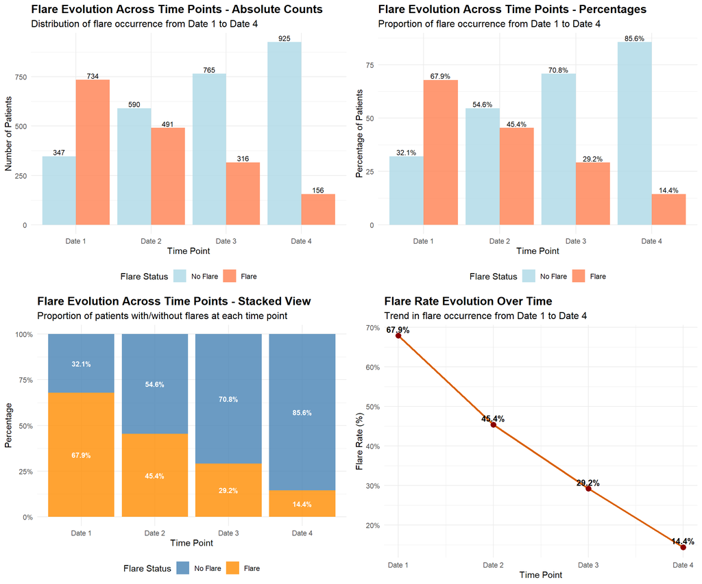

```r
# ===============================================================================
# 1. DEPENDENT VARIABLES ANALYSIS
# ===============================================================================



# Define dependent variables
dependent_vars <- c("flare_date1", "flare_date2", "flare_date3", "flare_date4")

print("=== DEPENDENT VARIABLES ANALYSIS ===")

# Summary of flare variables
flare_summary <- combined_dataset %>%
  dplyr::select(all_of(dependent_vars)) %>%
  dplyr::summarise(across(
    everything(),
    list(
      count_1 = ~sum(. == 1, na.rm = TRUE),
      count_0 = ~sum(. == 0, na.rm = TRUE),
      prop_1 = ~mean(. == 1, na.rm = TRUE),
      missing = ~sum(is.na(.))
    ),
    .names = "{.col}_{.fn}"
  ))

# Prepare flare evolution data
flare_evolution_data <- combined_dataset %>%
  dplyr::select(all_of(dependent_vars)) %>%
  pivot_longer(
    cols = everything(),
    names_to = "flare_timepoint",
    values_to = "flare_status"
  ) %>%
  filter(!is.na(flare_status)) %>%
  mutate(
    flare_timepoint = factor(
      flare_timepoint,
      levels = dependent_vars,
      labels = c("Date 1", "Date 2", "Date 3", "Date 4")
    ),
    flare_status = factor(
      flare_status,
      levels = c(0, 1),
      labels = c("No Flare", "Flare")
    )
  ) %>%
  group_by(flare_timepoint, flare_status) %>%
  summarise(count = n(), .groups = "drop") %>%
  group_by(flare_timepoint) %>%
  mutate(
    total = sum(count),
    percentage = round(count / total * 100, 1)
  )

# === Plot 1: Absolute Count ===
flare_evolution_plot_counts <- ggplot(flare_evolution_data,
                                      aes(x = flare_timepoint, y = count, fill = flare_status)) +
  geom_bar(stat = "identity", position = "dodge", alpha = 0.8) +
  geom_text(aes(label = count),
            position = position_dodge(width = 0.9),
            vjust = -0.25, size = 3) +
  scale_fill_manual(values = c("No Flare" = "lightblue", "Flare" = "coral")) +
  labs(title = "Flare Evolution Across Time Points - Absolute Counts",
       subtitle = "Distribution of flare occurrence from Date 1 to Date 4",
       x = "Time Point",
       y = "Number of Patients",
       fill = "Flare Status") +
  theme_minimal() +
  theme(
    plot.title = element_text(size = 14, face = "bold"),
    plot.subtitle = element_text(size = 12),
    legend.position = "bottom"
  )

# === Plot 2: Percentage ===
flare_evolution_plot_pct <- ggplot(flare_evolution_data,
                                   aes(x = flare_timepoint, y = percentage, fill = flare_status)) +
  geom_bar(stat = "identity", position = "dodge", alpha = 0.8) +
  geom_text(aes(label = paste0(percentage, "%")),
            position = position_dodge(width = 0.9),
            vjust = -0.25, size = 3) +
  scale_fill_manual(values = c("No Flare" = "lightblue", "Flare" = "coral")) +
  labs(title = "Flare Evolution Across Time Points - Percentages",
       subtitle = "Proportion of flare occurrence from Date 1 to Date 4",
       x = "Time Point",
       y = "Percentage of Patients",
       fill = "Flare Status") +
  theme_minimal() +
  theme(
    plot.title = element_text(size = 14, face = "bold"),
    plot.subtitle = element_text(size = 12),
    legend.position = "bottom"
  )

# === Plot 3: Stacked View ===
flare_evolution_plot_stacked <- ggplot(flare_evolution_data,
                                       aes(x = flare_timepoint, y = percentage, fill = flare_status)) +
  geom_bar(stat = "identity", position = "stack", alpha = 0.8) +
  geom_text(aes(label = paste0(percentage, "%")),
            position = position_stack(vjust = 0.5),
            size = 3, color = "white", fontface = "bold") +
  scale_fill_manual(values = c("No Flare" = "steelblue", "Flare" = "darkorange")) +
  scale_y_continuous(labels = function(x) paste0(x, "%")) +
  labs(title = "Flare Evolution Across Time Points - Stacked View",
       subtitle = "Proportion of patients with/without flares at each time point",
       x = "Time Point",
       y = "Percentage",
       fill = "Flare Status") +
  theme_minimal() +
  theme(
    plot.title = element_text(size = 14, face = "bold"),
    plot.subtitle = element_text(size = 12),
    legend.position = "bottom"
  )

# === Plot 4: Line Plot ===
flare_rates <- flare_evolution_data %>%
  filter(flare_status == "Flare") %>%
  mutate(timepoint_numeric = as.numeric(flare_timepoint))

flare_evolution_line <- ggplot(flare_rates, aes(x = timepoint_numeric, y = percentage)) +
  geom_line(color =  "#D95F02", size = 1.2) +
  geom_point(color = "darkred", size = 3) +
  geom_text(aes(label = paste0(percentage, "%")),
            vjust = -0.5, size = 3.5, fontface = "bold") +
  scale_x_continuous(breaks = 1:4, labels = c("Date 1", "Date 2", "Date 3", "Date 4")) +
  scale_y_continuous(labels = function(x) paste0(x, "%")) +
  labs(title = "Flare Rate Evolution Over Time",
       subtitle = "Trend in flare occurrence from Date 1 to Date 4",
       x = "Time Point",
       y = "Flare Rate (%)") +
  theme_minimal() +
  theme(
    plot.title = element_text(size = 14, face = "bold"),
    plot.subtitle = element_text(size = 12)
  )

# === Display All Plots ===
grid.arrange(
  flare_evolution_plot_counts, flare_evolution_plot_pct,
  flare_evolution_plot_stacked, flare_evolution_line,
  ncol = 2
)
```

```r
# === Summary Table ===
print("Flare evolution summary:")
flare_summary_table <- flare_evolution_data %>%
  dplyr::select(flare_timepoint, flare_status, count, percentage) %>%
  pivot_wider(
    names_from = flare_status,
    values_from = c(count, percentage),
    names_sep = "_"
  ) %>%
  arrange(flare_timepoint)

print(flare_summary_table)

## [1] "=== DEPENDENT VARIABLES ANALYSIS ==="
## [1] "Flare evolution summary:"
## # A tibble: 4 × 5
## # Groups:   flare_timepoint [4]
##   flare_timepoint `count_No Flare` count_Flare `percentage_No Flare`
##   <fct>                      <int>       <int>                 <dbl>
## 1 Date 1                       347         734                  32.1
## 2 Date 2                       590         491                  54.6
## 3 Date 3                       765         316                  70.8
## 4 Date 4                       925         156                  85.6
## # ℹ 1 more variable: percentage_Flare <dbl>
```

## 3.2 Factor features

evaluate each predictor variable against your four dependent variables (flare_date1, flare_date2, flare_date3, flare_date4). This will systematically test significance and provide data cleaning recommendations.

```r
summarize_chisq_for_factor <- function(df, predictor, flares = c("flare_date1", "flare_date2", "flare_date3", "flare_date4")) {
  # Treat 9999 as NA
  x_raw <- df[[predictor]]
  x <- factor(ifelse(as.character(x_raw) == "9999", NA, as.character(x_raw)))
  print(table(x, useNA = "ifany"))

  results <- lapply(flares, function(flare) {
    y <- df[[flare]]
    tbl <- table(x, y, useNA = "no")

    if (nrow(tbl) < 2 || ncol(tbl) < 2) {
      return(data.frame(Flare = flare, ChiSq = NA, df = NA, p_value = NA))
    }

    test_result <- suppressWarnings(chisq.test(tbl))

    data.frame(
      Flare = flare,
      ChiSq = round(test_result$statistic, 3),
      df = test_result$parameter,
      p_value = signif(test_result$p.value, 4),
      row.names = NULL  # <-- Ensures no row names

    )
  })

  result_df <- do.call(rbind, results)
  cat("\nChi-squared summary for predictor:", predictor, "\n")
  print(result_df)
  invisible(result_df)
}
```

```r
summarize_chisq_for_factor(combined_dataset, "DiseaseEntity")
## x
##  CD  UC
## 728 353
##
## Chi-squared summary for predictor: DiseaseEntity
##         Flare  ChiSq df   p_value
## 1 flare_date1 60.119  1 8.930e-15
## 2 flare_date2 37.745  1 8.061e-10
## 3 flare_date3 25.353  1 4.774e-07
## 4 flare_date4 14.397  1 1.480e-04
```

```r
summarize_chisq_for_factor(combined_dataset, "gender")
## x
## Female   Male
##    593    488
##
## Chi-squared summary for predictor: gender
##         Flare ChiSq df  p_value
## 1 flare_date1 5.039  1 0.024780
## 2 flare_date2 4.276  1 0.038650
## 3 flare_date3 7.113  1 0.007654
## 4 flare_date4 2.492  1 0.114400
```

```r
summarize_chisq_for_factor(combined_dataset, "montreal_extent_uc")
## x
##    1    2    3 <NA>
##   29  119  213  720
##
## Chi-squared summary for predictor: montreal_extent_uc
##         Flare ChiSq df p_value
## 1 flare_date1 3.936  2  0.1398
## 2 flare_date2 1.146  2  0.5639
## 3 flare_date3 2.681  2  0.2617
## 4 flare_date4 1.638  2  0.4410
```

```r
summarize_chisq_for_factor(combined_dataset, "montreal_severity_uc")
## x
##   0   1   2   3
## 764 157 123  37
##
## Chi-squared summary for predictor: montreal_severity_uc
##         Flare  ChiSq df   p_value
## 1 flare_date1 49.459  3 1.042e-10
## 2 flare_date2 27.860  3 3.886e-06
## 3 flare_date3 25.961  3 9.716e-06
## 4 flare_date4 18.699  3 3.155e-04
```

create a binary variable where:

0 = no severity (original value 0) 1 = any severity (original values 1, 2, or 3)

```r
# Recode factor montreal_severity_uc into binary
combined_dataset <- combined_dataset %>%
  mutate(montreal_severity_uc = case_when(
    as.character(montreal_severity_uc) == "0" ~ "0",
    as.character(montreal_severity_uc) %in% c("1", "2", "3") ~ "1",
    TRUE ~ as.character(montreal_severity_uc)  # Keep any other values unchanged
  ))

summarize_chisq_for_factor(combined_dataset, "montreal_severity_uc")
combined_dataset$montreal_severity_uc <- factor(combined_dataset$montreal_severity_uc)
## x
##   0   1
## 764 317
##
## Chi-squared summary for predictor: montreal_severity_uc
##         Flare  ChiSq df   p_value
## 1 flare_date1 45.733  1 1.355e-11
## 2 flare_date2 25.341  1 4.805e-07
## 3 flare_date3 15.536  1 8.094e-05
## 4 flare_date4 10.145  1 1.447e-03
```

```r
summarize_chisq_for_factor(combined_dataset, "montreal_age_cd")
## x
##    0    1 <NA>
##  507  186  388
##
## Chi-squared summary for predictor: montreal_age_cd
##         Flare ChiSq df p_value
## 1 flare_date1 0.437  1  0.5085
## 2 flare_date2 0.205  1  0.6511
## 3 flare_date3 0.168  1  0.6822
## 4 flare_date4 1.500  1  0.2207
```

```r
summarize_chisq_for_factor(combined_dataset, "surg_colon_resection")
## x
##    0    1
## 1047   34
##
## Chi-squared summary for predictor: surg_colon_resection
##         Flare ChiSq df p_value
## 1 flare_date1 0.350  1  0.5538
## 2 flare_date2 0.000  1  0.9841
## 3 flare_date3 0.000  1  1.0000
## 4 flare_date4 1.654  1  0.1984
```

```r
summarize_chisq_for_factor(combined_dataset, "surg_subtotal_colectomy")
## x
##    0    1
## 1057   24
##
## Chi-squared summary for predictor: surg_subtotal_colectomy
##         Flare ChiSq df p_value
## 1 flare_date1 1.528  1  0.2163
## 2 flare_date2 0.991  1  0.3195
## 3 flare_date3 0.055  1  0.8149
## 4 flare_date4 0.000  1  1.0000
```

```r
summarize_chisq_for_factor(combined_dataset, "surg_fistula_abcess")
## x
##    0    1
## 1002   79
##
## Chi-squared summary for predictor: surg_fistula_abcess
##         Flare ChiSq df p_value
## 1 flare_date1 0.618  1  0.4317
## 2 flare_date2 0.000  1  1.0000
## 3 flare_date3 0.168  1  0.6822
## 4 flare_date4 0.000  1  1.0000
```

```r
summarize_chisq_for_factor(combined_dataset, "surg_ileo_anal_pouch")
## x
##    0    1
## 1074    7
##
## Chi-squared summary for predictor: surg_ileo_anal_pouch
##         Flare ChiSq df p_value
## 1 flare_date1 0.042  1  0.8372
## 2 flare_date2 1.636  1  0.2009
## 3 flare_date3 1.662  1  0.1974
## 4 flare_date4 0.303  1  0.5820
```

```r
summarize_chisq_for_factor(combined_dataset, "surg_small_bowel_resection")
## x
##    0    1
## 1045   36
##
## Chi-squared summary for predictor: surg_small_bowel_resection
##         Flare ChiSq df p_value
## 1 flare_date1 2.051  1  0.1521
## 2 flare_date2 0.084  1  0.7719
## 3 flare_date3 0.146  1  0.7028
## 4 flare_date4 1.236  1  0.2662
```

```r
summarize_chisq_for_factor(combined_dataset, "surg_ileocaecal_resection")
## x
##   0   1
## 963 118
##
## Chi-squared summary for predictor: surg_ileocaecal_resection
##         Flare ChiSq df  p_value
## 1 flare_date1 9.332  1 0.002252
## 2 flare_date2 1.426  1 0.232400
## 3 flare_date3 0.412  1 0.520800
## 4 flare_date4 0.022  1 0.883300
```

```r
summarize_chisq_for_factor(combined_dataset, "surg_small_bowel_stoma")
## x
##    0    1
## 1042   39
##
## Chi-squared summary for predictor: surg_small_bowel_stoma
##         Flare ChiSq df p_value
## 1 flare_date1 1.934  1  0.1643
## 2 flare_date2 1.109  1  0.2924
## 3 flare_date3 0.001  1  0.9716
## 4 flare_date4 0.755  1  0.3850
```

```r
summarize_chisq_for_factor(combined_dataset, "surg_colostoma")
## x
##    0    1
## 1069   12
##
## Chi-squared summary for predictor: surg_colostoma
##         Flare ChiSq df p_value
## 1 flare_date1 0.048  1  0.8268
## 2 flare_date2 0.000  1  1.0000
## 3 flare_date3 0.000  1  0.9960
## 4 flare_date4 0.000  1  1.0000
```

```r
summarize_chisq_for_factor(combined_dataset, "surg_proctocolectomy")
## x
##    0    1
## 1076    5
##
## Chi-squared summary for predictor: surg_proctocolectomy
##         Flare ChiSq df p_value
## 1 flare_date1 0.010  1  0.9197
## 2 flare_date2 2.542  1  0.1108
## 3 flare_date3 0.898  1  0.3433
## 4 flare_date4 0.080  1  0.7775
```

```r
summarize_chisq_for_factor(combined_dataset, "surg_stoma_reversal")
## x
##    0    1
## 1051   30
##
## Chi-squared summary for predictor: surg_stoma_reversal
##         Flare ChiSq df p_value
## 1 flare_date1 3.731  1 0.05342
## 2 flare_date2 0.000  1 1.00000
## 3 flare_date3 0.088  1 0.76620
## 4 flare_date4 0.008  1 0.92830
```

```r
summarize_chisq_for_factor(combined_dataset, "surg_proctectomy")
## x
##    0    1
## 1078    3
##
## Chi-squared summary for predictor: surg_proctectomy
##         Flare ChiSq df p_value
## 1 flare_date1 0.329  1  0.5664
## 2 flare_date2 1.003  1  0.3165
## 3 flare_date3 0.230  1  0.6318
## 4 flare_date4 0.000  1  1.0000
```

```r
summarize_chisq_for_factor(combined_dataset, "surg_stenoplasty")
## x
##    0    1
## 1076    5
##
## Chi-squared summary for predictor: surg_stenoplasty
##         Flare ChiSq df p_value
## 1 flare_date1 0.000  1  1.0000
## 2 flare_date2 0.482  1  0.4876
## 3 flare_date3 0.898  1  0.3433
## 4 flare_date4 0.080  1  0.7775
```

```r
summarize_chisq_for_factor(combined_dataset, "Family_IBD_final")
## x
##    0    1 <NA>
##  483  102  496
##
## Chi-squared summary for predictor: Family_IBD_final
##         Flare ChiSq df p_value
## 1 flare_date1 1.441  1 0.23000
## 2 flare_date2 3.036  1 0.08143
## 3 flare_date3 2.085  1 0.14880
## 4 flare_date4 4.048  1 0.04423
```

```r
summarize_chisq_for_factor(combined_dataset, "History_colitis")
## x
##    0    1 <NA>
##  510   42  529
##
## Chi-squared summary for predictor: History_colitis
##         Flare ChiSq df p_value
## 1 flare_date1 3.113  1 0.07767
## 2 flare_date2 2.651  1 0.10350
## 3 flare_date3 3.316  1 0.06860
## 4 flare_date4 1.949  1 0.16270
```

```r
summarize_chisq_for_factor(combined_dataset, "History_crohn")
## x
##    0    1 <NA>
##  476   75  530
##
## Chi-squared summary for predictor: History_crohn
##         Flare ChiSq df p_value
## 1 flare_date1 0.667  1  0.4139
## 2 flare_date2 0.000  1  1.0000
## 3 flare_date3 0.545  1  0.4605
## 4 flare_date4 0.882  1  0.3475
```

```r
summarize_chisq_for_factor(combined_dataset, "smoker")
## x
##    1    2    3    4 <NA>
##  433  230  154   43  221
##
## Chi-squared summary for predictor: smoker
##         Flare  ChiSq df  p_value
## 1 flare_date1  9.626  3 0.022030
## 2 flare_date2 11.606  3 0.008863
## 3 flare_date3  6.387  3 0.094240
## 4 flare_date4  7.466  3 0.058450
```

## 3.3 numeric features

```r
library(patchwork)
library(caret)

analyze_numeric_predictor <- function(df, predictor,Process=FALSE, flares = c("flare_date1", "flare_date2", "flare_date3", "flare_date4")) {
  cat("\n========== ANALYSIS FOR:", predictor, "==========\n")

  x_raw <- df[[predictor]]
  if (!is.numeric(x_raw)) {
    cat("Skipping: not a numeric variable.\n")
    return(NULL)
  }

  # Treat 9999 as NA
  x <- ifelse(x_raw == 9999, NA, x_raw)

  ## === 1. Raw histogram ===
  hist(x, main = paste(predictor, "(Raw Histogram)"), xlab = predictor, col = "skyblue", border = "white")

  ## === 2. Histograms and Boxplots ===
  hist_list <- list()
  box_list <- list()

  for (i in seq_along(flares)) {
    flare <- flares[i]
    df_flare <- df %>%
      mutate(
        flare_val = factor(.data[[flare]]),
        predictor_val = ifelse(x_raw == 9999, NA, x_raw)
      ) %>%
      filter(!is.na(predictor_val), !is.na(flare_val))

    # Histogram
    hist_list[[i]] <- ggplot(df_flare, aes(x = predictor_val, fill = flare_val)) +
      geom_histogram(position = "identity", bins = 30, alpha = 0.5) +
      labs(title = paste("Histogram:", flare), fill = flare) +
      theme_minimal()

    # Boxplot
    box_list[[i]] <- ggplot(df_flare, aes(x = flare_val, y = predictor_val)) +
      geom_boxplot(fill = "orange") +
      labs(title = paste("Boxplot:", flare), x = flare, y = predictor) +
      theme_minimal()
  }

  ## === 3. Show plots ===
  cat("\n== Displaying 4 Histograms ==\n")
  print(wrap_plots(hist_list, ncol = 2))

  cat("\n== Displaying 4 Boxplots ==\n")
  print(wrap_plots(box_list, ncol = 2))

  ## === 4. Box-Cox with caret ===
  df_valid <- df %>% select(all_of(flares)) %>% mutate(predictor_val = x)
  df_valid <- df_valid[complete.cases(df_valid), ]

  # Make strictly positive if needed (Box-Cox requires > 0)
  min_val <- min(df_valid$predictor_val, na.rm = TRUE)
  if (min_val <= 0) {
    df_valid$predictor_val <- df_valid$predictor_val + abs(min_val) + 1
  }

  # Apply Box-Cox via caret
  pp <- preProcess(as.data.frame(df_valid$predictor_val), method =  c("BoxCox", "center", "scale"))
  df_valid$predictor_boxcox <- predict(pp, as.data.frame(df_valid$predictor_val))[[1]]

  ## === 5. T-tests ===
  t_results <- lapply(flares, function(flare) {
    y <- df_valid[[flare]]
    if (length(unique(y)) != 2) return(NULL)
    test <- t.test(df_valid$predictor_boxcox ~ y)
    data.frame(
      Dependent = flare,
      t_stat = round(test$statistic, 3),
      df = round(test$parameter, 1),
      p_value = format.pval(test$p.value, digits = 4, eps = .0001),
      row.names = NULL
    )
  })

  t_table <- do.call(rbind, t_results)
  cat("\n== T-test Results on Box-Cox Transformed Predictor ==\n")
  print(t_table, row.names = FALSE)


  ## === 6. Replace raw predictor with processed values in df ===
  if (Process) {
    transformed_full <- rep(NA, nrow(df))
    transformed_full[as.numeric(rownames(df_valid))] <- df_valid$predictor_boxcox
    #df[[predictor]] <- transformed_full
    return(transformed_full)
  }

  # If not processing, return df unchanged invisibly

}
```

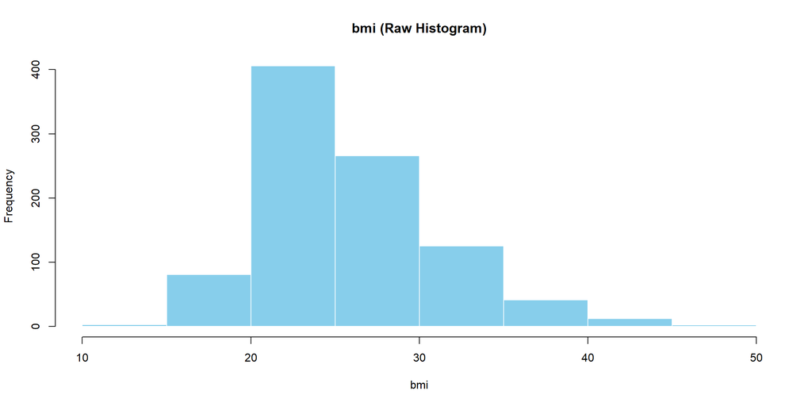

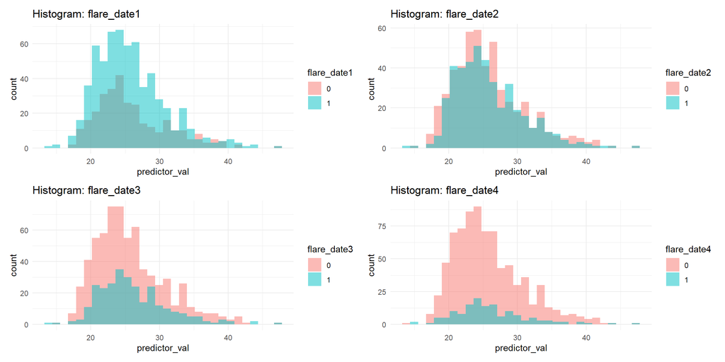

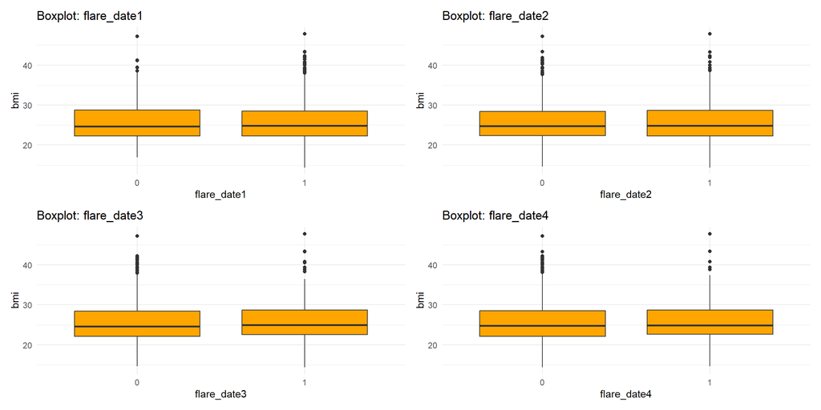

```
##
## ========== ANALYSIS FOR: bmi ==========
##
## == Displaying 4 Histograms ==
##
## == Displaying 4 Boxplots ==
##
## == T-test Results on Box-Cox Transformed Predictor ==
##    Dependent t_stat    df p_value
##  flare_date1  0.774 602.8  0.4393
##  flare_date2 -0.278 920.6  0.7811
##  flare_date3 -1.224 529.7  0.2214
##  flare_date4 -0.435 185.9  0.6638
```

```r
analyze_numeric_predictor(combined_dataset, "bmi")
```

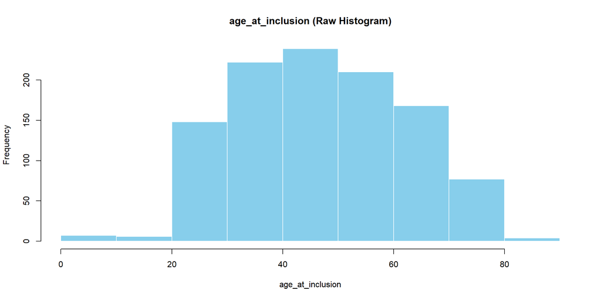

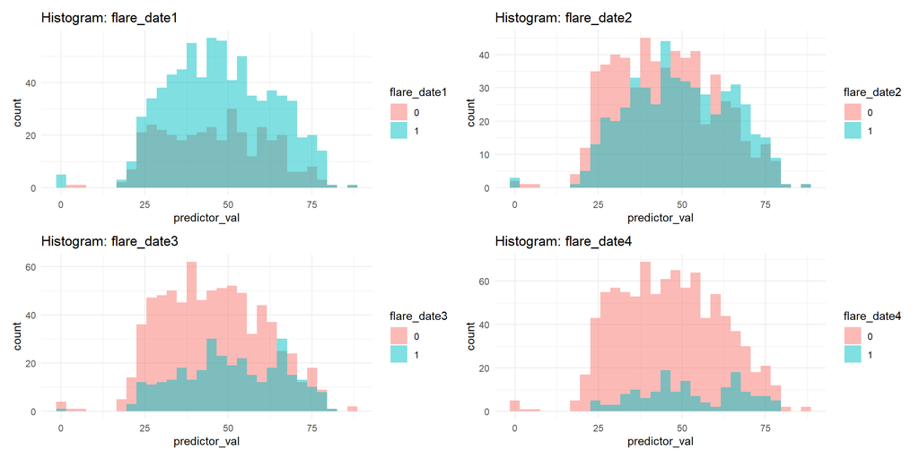

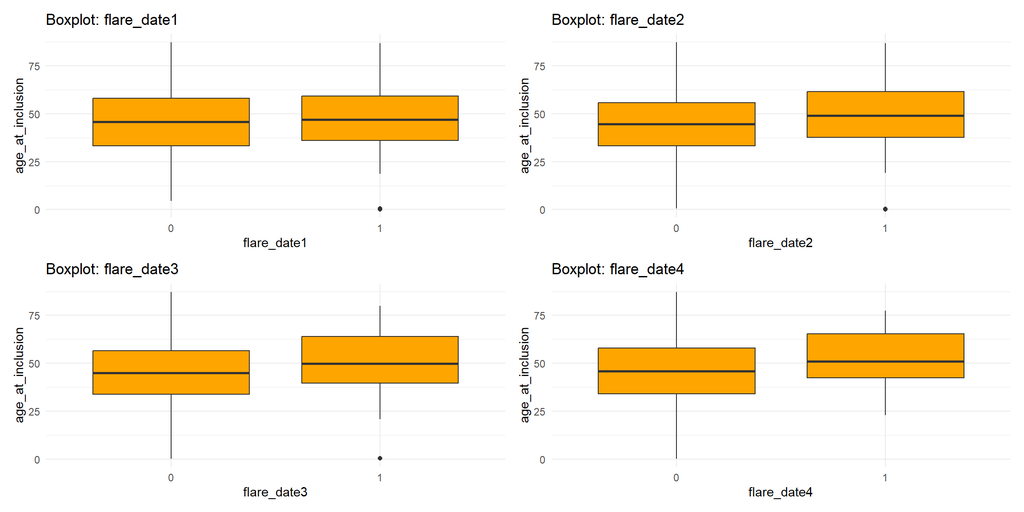

```
##
## ========== ANALYSIS FOR: age_at_inclusion ==========
##
## == Displaying 4 Histograms ==
##
## == Displaying 4 Boxplots ==
##
## == T-test Results on Box-Cox Transformed Predictor ==
##    Dependent t_stat     df p_value
##  flare_date1 -1.771  677.0   0.077
##  flare_date2 -4.733 1044.2 < 1e-04
##  flare_date3 -5.174  585.8 < 1e-04
##  flare_date4 -4.860  215.9 < 1e-04
```

```r
analyze_numeric_predictor(combined_dataset, "age_at_inclusion")
```

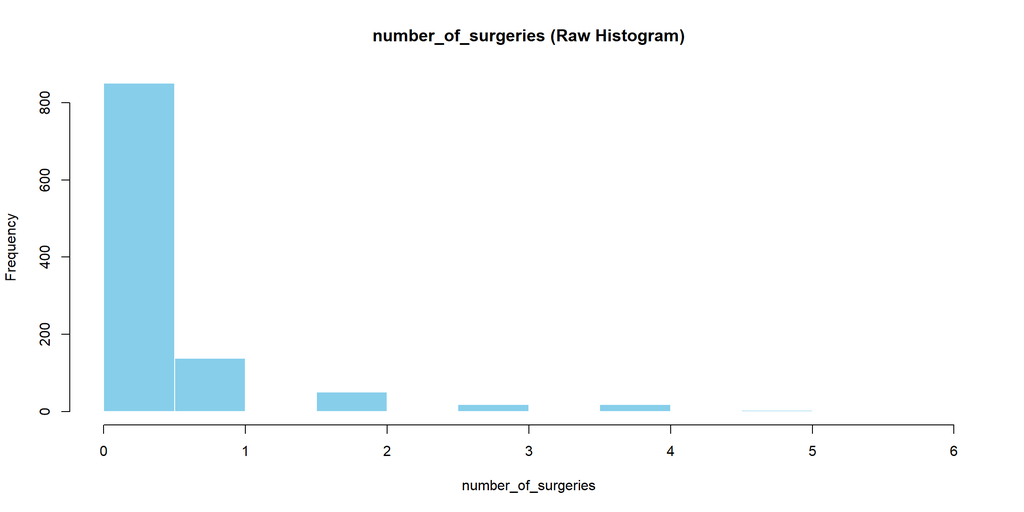

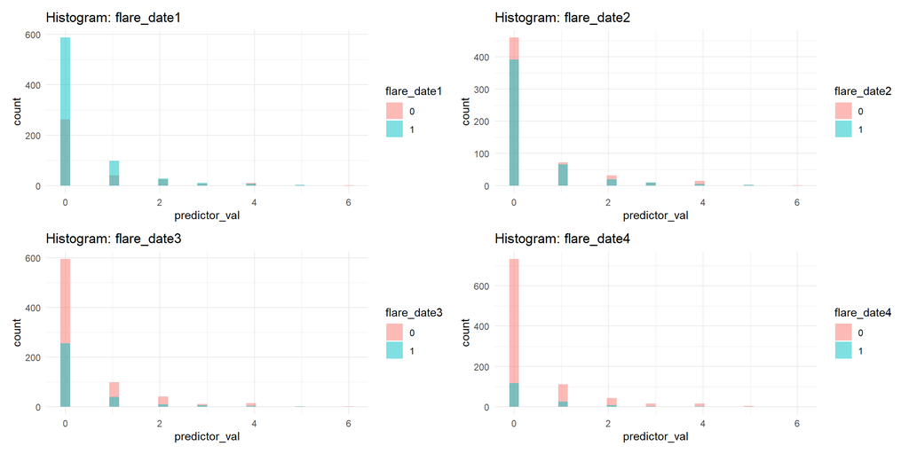

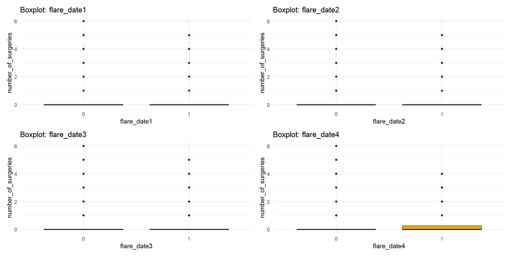

```
##
## ========== ANALYSIS FOR: number_of_surgeries ==========
##
## == Displaying 4 Histograms ==
##
## == Displaying 4 Boxplots ==
##
## == T-test Results on Box-Cox Transformed Predictor ==
##    Dependent t_stat     df p_value
##  flare_date1  1.877  615.0  0.0611
##  flare_date2  0.860 1060.6  0.3902
##  flare_date3  1.096  619.5  0.2735
##  flare_date4 -1.066  204.8  0.2879
```

```r
analyze_numeric_predictor(combined_dataset, "number_of_surgeries")
```

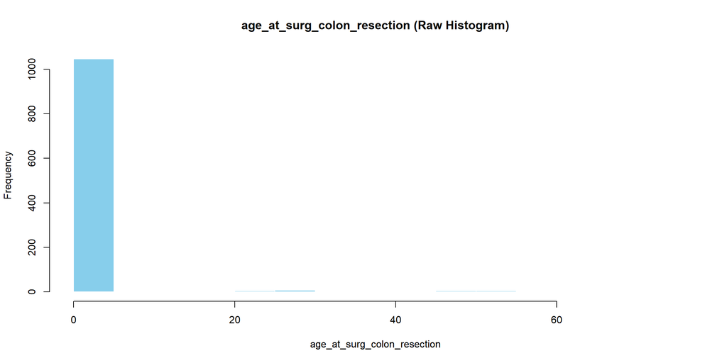

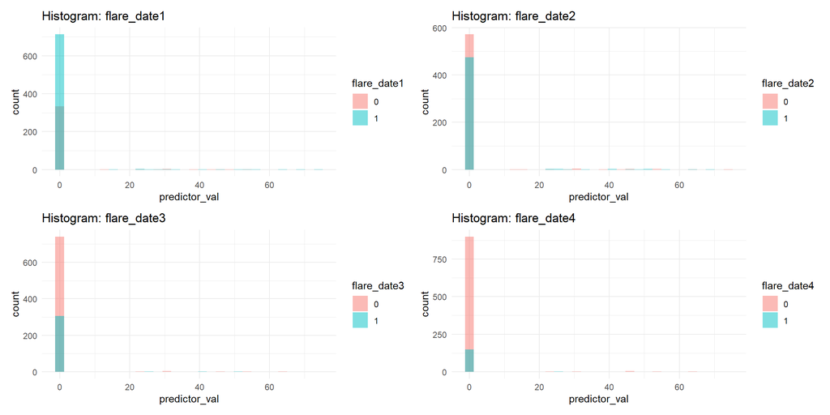

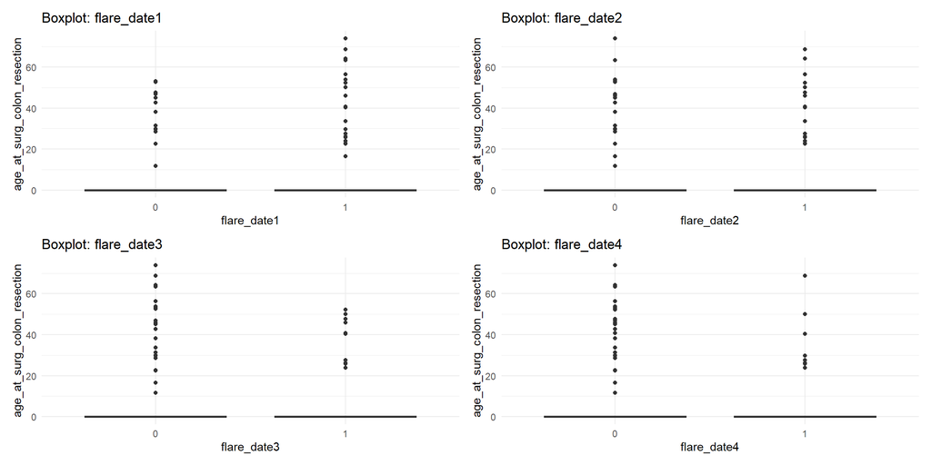

```
##
## ========== ANALYSIS FOR: age_at_surg_colon_resection ==========
##
## == Displaying 4 Histograms ==
##
## == Displaying 4 Boxplots ==
##
## == T-test Results on Box-Cox Transformed Predictor ==
##    Dependent t_stat     df p_value
##  flare_date1  0.742  605.8  0.4585
##  flare_date2 -0.195 1030.8  0.8454
##  flare_date3 -0.024  584.8  0.9809
##  flare_date4 -1.251  185.3  0.2127
```

```r
analyze_numeric_predictor(combined_dataset, "age_at_surg_colon_resection")
```

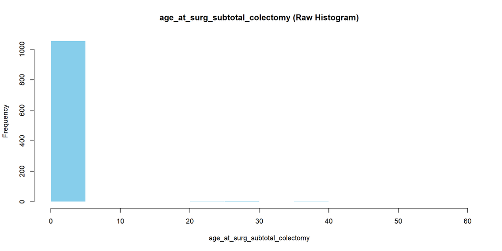

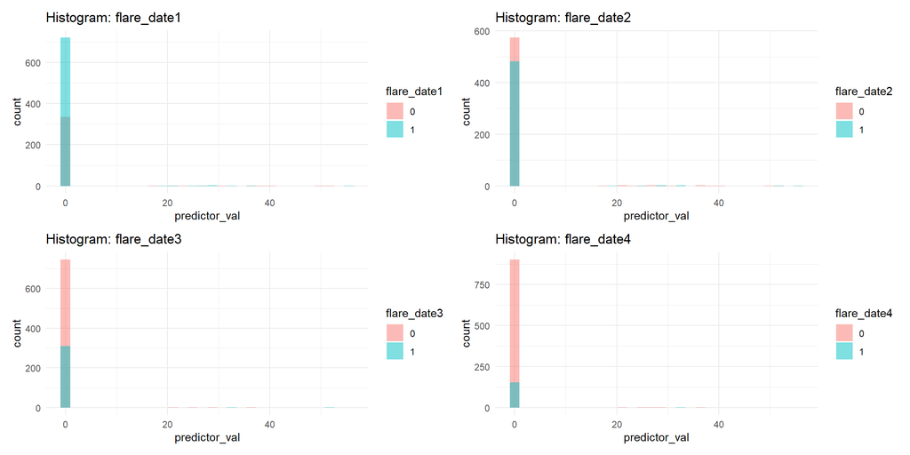

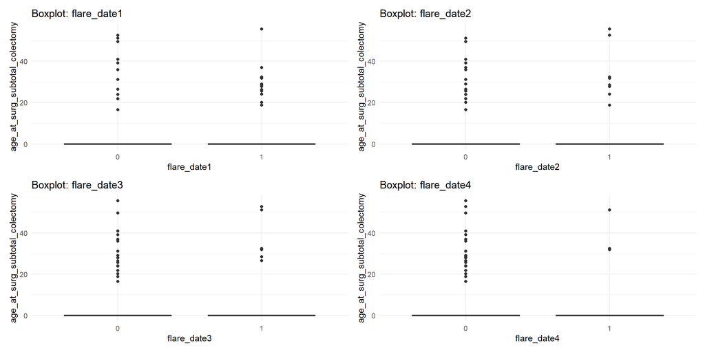

```
##
## ========== ANALYSIS FOR: age_at_surg_subtotal_colectomy ==========
##
## == Displaying 4 Histograms ==
##
## == Displaying 4 Boxplots ==
##
## == T-test Results on Box-Cox Transformed Predictor ==
##    Dependent t_stat     df p_value
##  flare_date1  1.319  537.7  0.1876
##  flare_date2  1.229 1074.6  0.2192
##  flare_date3  0.480  647.5  0.6315
##  flare_date4  0.287  220.7  0.7746
```

```r
analyze_numeric_predictor(combined_dataset, "age_at_surg_subtotal_colectomy")
```

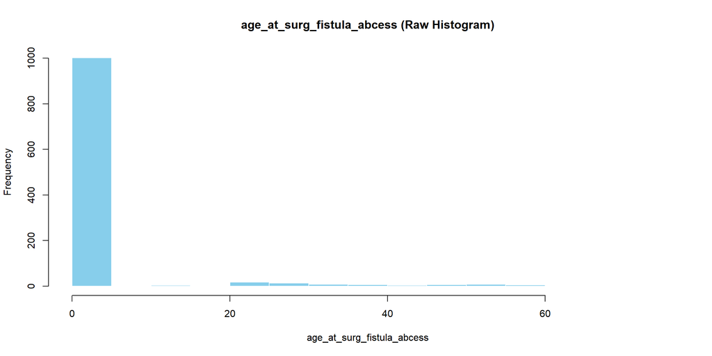

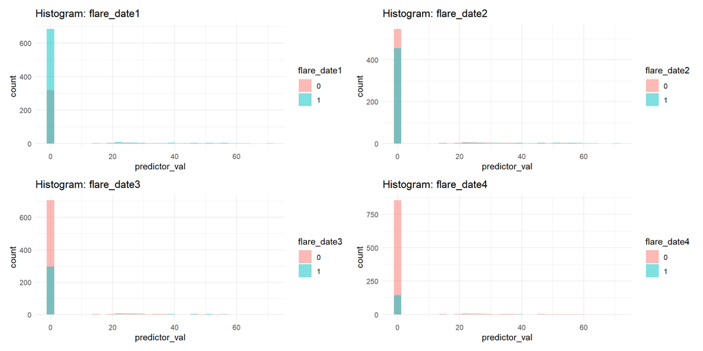

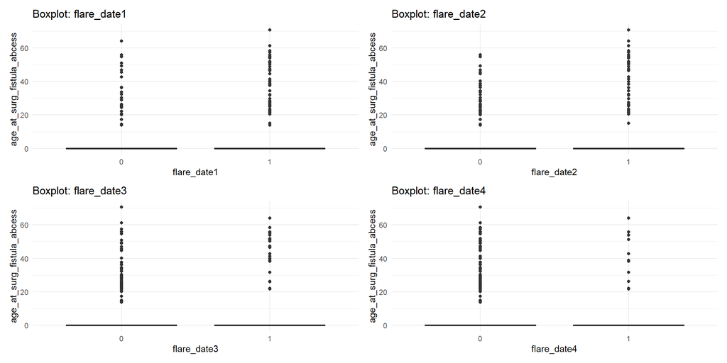

```
##
## ========== ANALYSIS FOR: age_at_surg_fistula_abcess ==========
##
## == Displaying 4 Histograms ==
##
## == Displaying 4 Boxplots ==
##
## == T-test Results on Box-Cox Transformed Predictor ==
##    Dependent t_stat     df p_value
##  flare_date1  0.879  624.7  0.3795
##  flare_date2 -0.030 1042.3  0.9762
##  flare_date3  0.548  620.7  0.5838
##  flare_date4  0.133  212.6  0.8941
```

```r
analyze_numeric_predictor(combined_dataset, "age_at_surg_fistula_abcess")
```

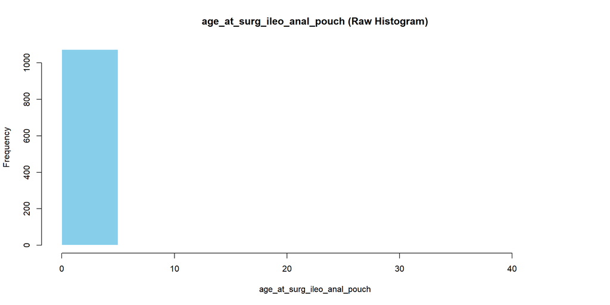

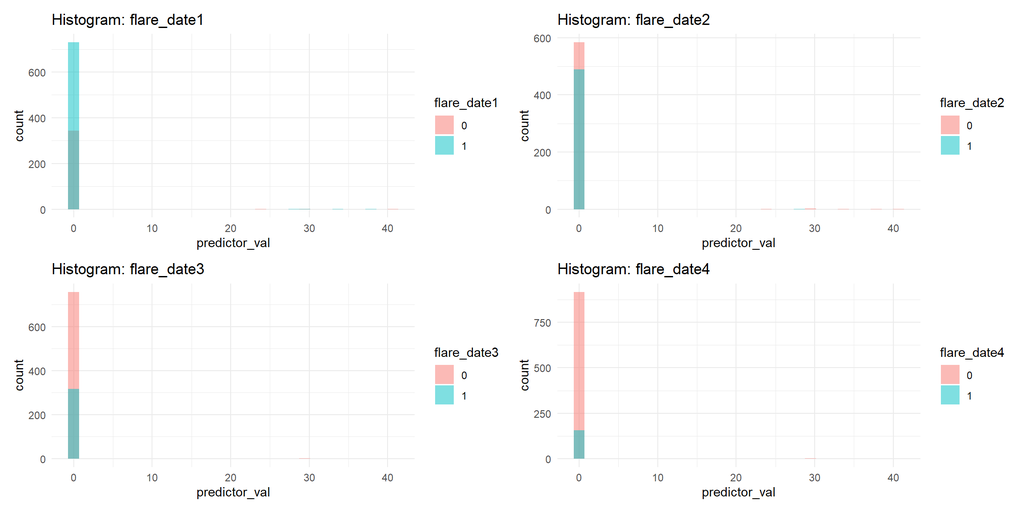

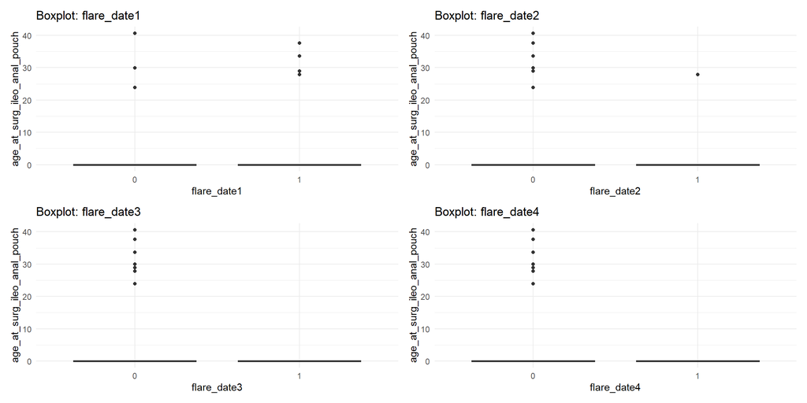

```
##
## ========== ANALYSIS FOR: age_at_surg_ileo_anal_pouch ==========
##
## == Displaying 4 Histograms ==
##
## == Displaying 4 Boxplots ==
##
## == T-test Results on Box-Cox Transformed Predictor ==
##    Dependent t_stat    df p_value
##  flare_date1  0.563 559.9  0.5734
##  flare_date2  1.765 849.4  0.0779
##  flare_date3  2.656 764.0  0.0081
##  flare_date4  2.654 924.0  0.0081
```

```r
analyze_numeric_predictor(combined_dataset, "age_at_surg_ileo_anal_pouch")
```

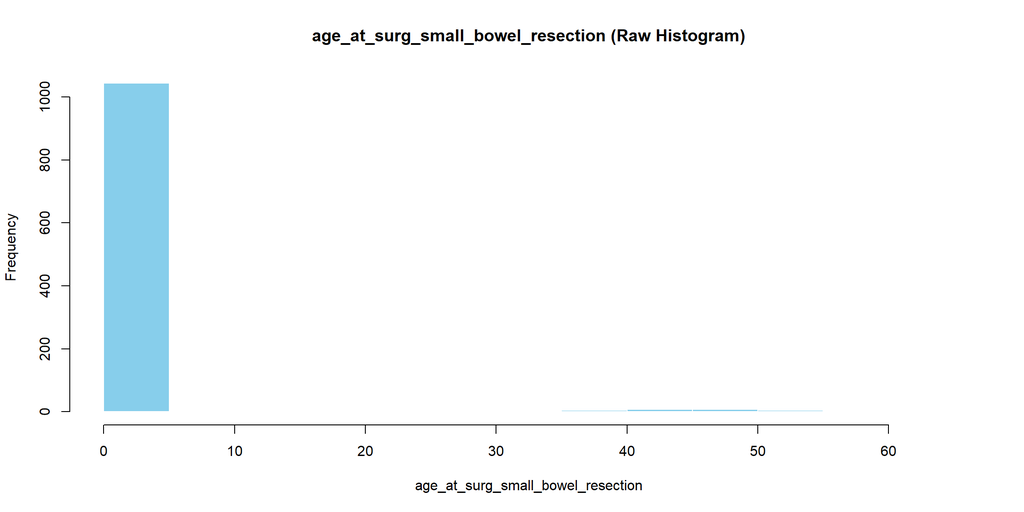

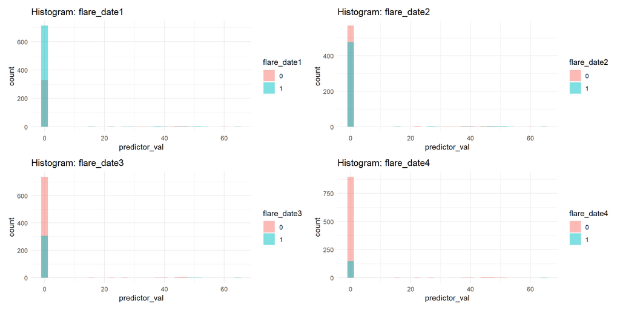

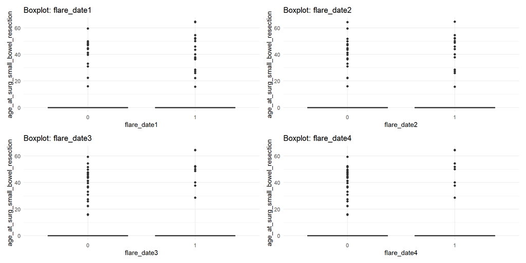

```
##
## ========== ANALYSIS FOR: age_at_surg_small_bowel_resection ==========
##
## == Displaying 4 Histograms ==
##
## == Displaying 4 Boxplots ==
##
## == T-test Results on Box-Cox Transformed Predictor ==
##    Dependent t_stat     df p_value
##  flare_date1  1.476  549.8  0.1405
##  flare_date2  0.463 1066.0  0.6435
##  flare_date3  0.591  646.8  0.5548
##  flare_date4 -1.131  187.6  0.2596
```

```r
analyze_numeric_predictor(combined_dataset, "age_at_surg_small_bowel_resection")
```

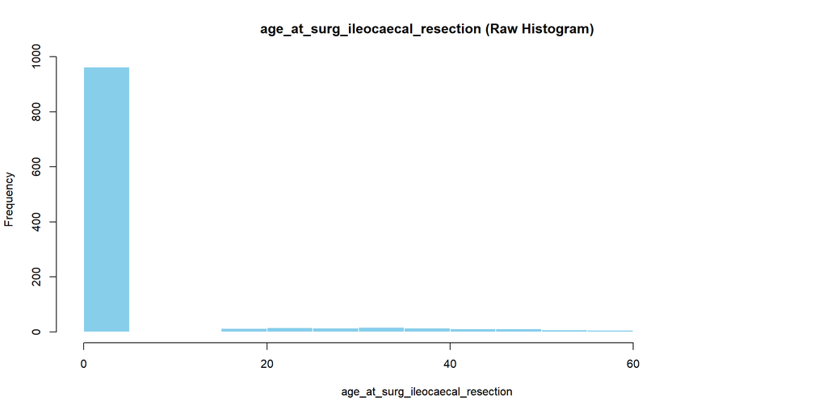

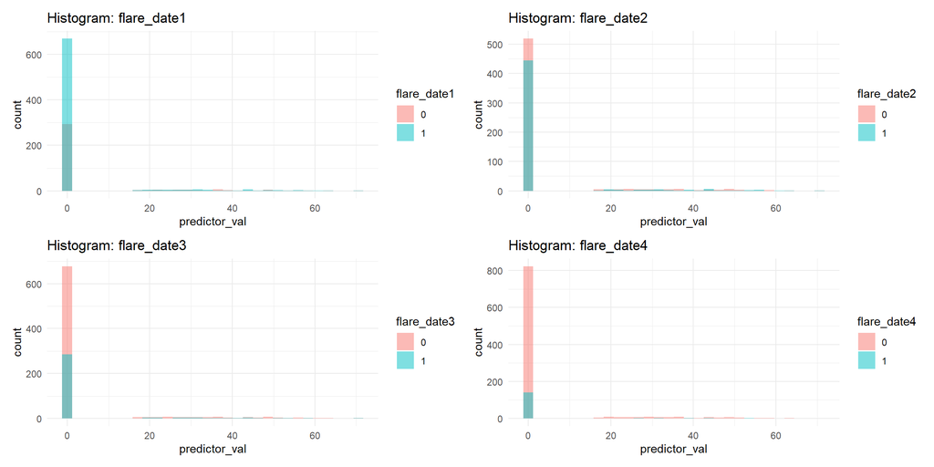

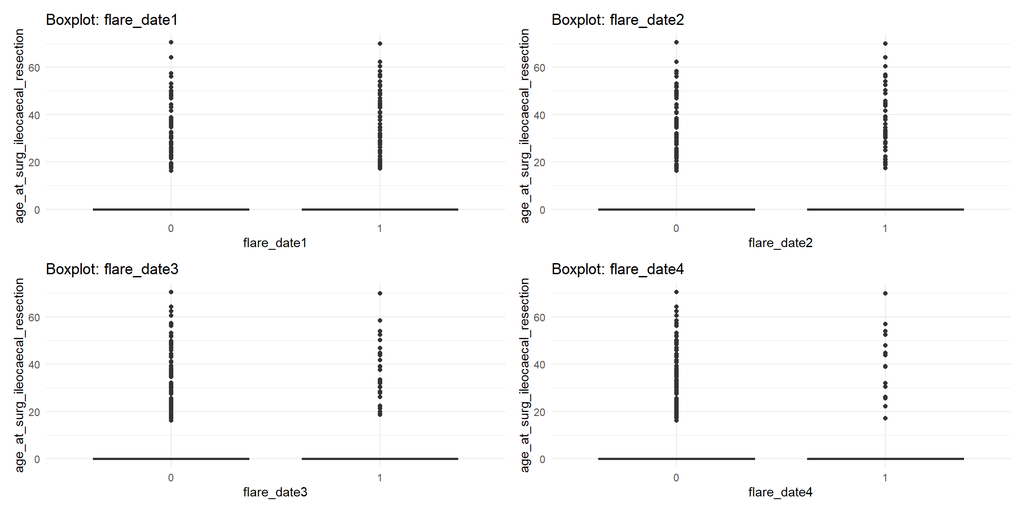

```
##
## ========== ANALYSIS FOR: age_at_surg_ileocaecal_resection ==========
##
## == Displaying 4 Histograms ==
##
## == Displaying 4 Boxplots ==
##
## == T-test Results on Box-Cox Transformed Predictor ==
##    Dependent t_stat     df p_value
##  flare_date1  2.917  557.0  0.0037
##  flare_date2  1.304 1071.5  0.1926
##  flare_date3  0.769  623.6  0.4424
##  flare_date4  0.291  214.2  0.7716
```

```r
analyze_numeric_predictor(combined_dataset, "age_at_surg_ileocaecal_resection")
```